# Re_Airquality

Maelle Cosandey

2025-03-11

## Introduction

The dataset contains daily air quality measurements in New York, for the period first of May 1973 to 30th September 1973. The different variables are ozone concentration [ppb], solar radiation [lang], wind speed [miles/hour], temperature [°F] and time [day and months]. It’s important to notice that some units are quite unusual

Because ozone presence in the troposphere is toxic, the aim of this study will be to determine which meteorological variables (wind speed, radiation and temperature) have an influence on ozone formation. The hypothesis is that temperature and radiation will be positively correlated with ozone concentration, and wind negatively correlated.

## Data

At first, the missing values have been removed

```r
Data <- na.omit(Data)
```

Then a summary of the data has been made, to visualize the mean and the variation of the different variables

```r
# Compute mean and std
small_Data <- Data %>%
  dplyr::select(Ozone, Solar.R, Wind, Temp)

summary_table <- small_Data %>%
  summarise(across(everything(), list(
    Mean = ~ mean(.x, na.rm = TRUE),
    Std = ~ sd(.x, na.rm = TRUE)
  )))

# Transpose to present
summary_table_t <- summary_table %>%
  tidyr::pivot_longer(everything(),
                      names_to = c("Variable", ".value"),
                      names_sep = "_")

# present
kable(summary_table_t, caption = "Summary of the variables")
```

Summary of the variables

| Variable | Mean | Std |
| --- | --- | --- |
| Ozone | 42.09910 | 33.275969 |
| Solar.R | 184.80180 | 91.152302 |
| Wind | 9.93964 | 3.557713 |
| Temp | 77.79279 | 9.529969 |

## Analysis

At first a time serie of ozone concentration has been made, showing ozone evolution through time

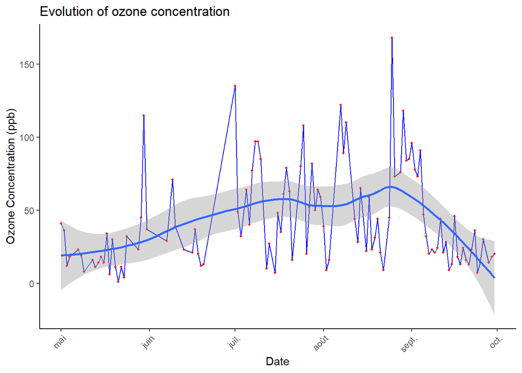

```r
# Crate a date column
Data$Date <- as.Date(paste(Data$Month, Data$Day, "1973", sep = "-"), format = "%m-%d-%Y")  #
#Assumes a common year

# Time serie
ozone_time_plot <- ggplot(data = Data, aes(x = Date, y = Ozone)) +
  geom_line(color = "blue") +
  geom_point(color = "red", size = 0.75) +
  geom_smooth(method = "loess", span = 0.5) +
  labs(x = "Date",
       y = "Ozone Concentration (ppb)",
       title = "Evolution of ozone concentration") +
  theme_classic() +
  theme(axis.text.x = element_text(angle = 45, hjust = 1))

#Print plot
print(ozone_time_plot)
```

Then, scatter plot showing ozone concentration with every other variable, to visualize their link.

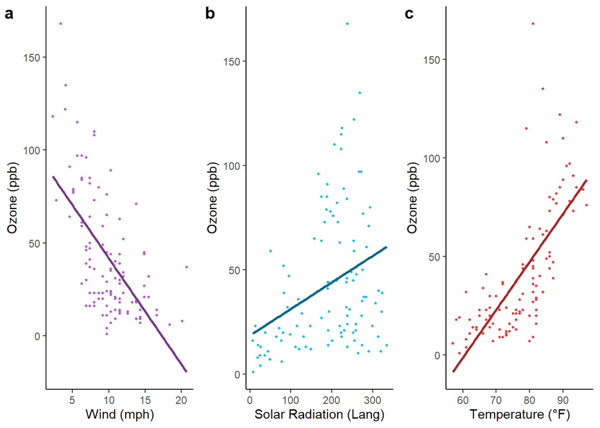

```r
# Ozone vs Wind
plot_1 <- ggplot(data = Data, aes(x = Wind, y = Ozone)) +
  geom_point(size = 0.75, color = "mediumorchid") +
  geom_smooth(method = "lm", color = "mediumorchid4", se = FALSE) +
  labs(x = "Wind (mph)",
       y = "Ozone (ppb)") +
  theme_classic()

# Ozone vs Solar.R
plot_2 <- ggplot(data = Data, aes(x = Solar.R, y = Ozone)) +
  geom_point(size = 0.75, color="deepskyblue" ) +
  geom_smooth(method = "lm", color = "deepskyblue4", se = FALSE) +
  labs(x = "Solar Radiation (Lang)",
       y = "Ozone (ppb)") +
  theme_classic()

# Ozone vs Temperature
plot_3 <- ggplot(data = Data, aes(x = Temp, y = Ozone)) +
  geom_point(size = 0.75, color="firebrick1") +
  geom_smooth(method = "lm", color = "firebrick", se = FALSE) +
  labs(x = "Temperature (°F)",
       y = "Ozone (ppb)") +
  theme_classic()

# Combine plot
cowplot::plot_grid(plot_1, plot_2, plot_3, ncol = 3, labels = "auto")
```

## Conclusion

As excpected, temperature and radiation is positively correlated with ozone concentration, and wind is negatively correlated. But because temperature is already correlated with radiation, it seems interesting to explore the partial correlation between temperature and ozone concentration, to understand if temperature has an influence of ozone directly.

```r
pcor.test(Data$Ozone, Data$Temp, Data$Solar.R)
```

```
##   estimate      p.value statistic   n gp  Method
## 1 0.665351 2.215559e-15  9.262218 111  1 pearson
```

```r
pcor.test(Data$Ozone, Data$Solar.R, Data$Temp)
```

```
##    estimate    p.value statistic   n gp  Method
## 1 0.2089543 0.02847063  2.220534 111  1 pearson
```

This test suggest that temperature significantly influences Ozone independently of Solar Radiation.Solar Radiation’s effect on Ozone is partly mediated by Temperature. In the data controlling for Temperature reduces the strength of the correlation between Ozone and Solar Radiation.